# HW5 Class Demo Notes

Guided hints for random-effects ANOVA, MLE, REML, and shrinkage

Published

May 18, 2026

## Summary

1. SSE estimates only within-group noise.
2. SSA estimates between-group variation plus averaged noise.
3. MLE and REML differ mainly in how they account for estimating the fixed effect.
4. Random-effect predictions are shrunken versions of group fixed-effect estimates.

## Data preview: the motivating question

Use the `pulp` data as the concrete example.

```r
data(pulp, package = "faraway")
head(pulp)
```

```
  bright operator
1   59.8        a
2   60.0        a
3   60.8        a
4   60.8        a
5   59.8        a
6   59.8        b
```

```r
pulp |>
  group_by(operator) |>
  summarize(
    n = n(),
    mean_bright = mean(bright),
    .groups = "drop"
  )
```

```
# A tibble: 4 × 3
  operator     n mean_bright
  <fct>    <int>       <dbl>
1 a            5        60.2
2 b            5        60.1
3 c            5        60.6
4 d            5        60.7
```

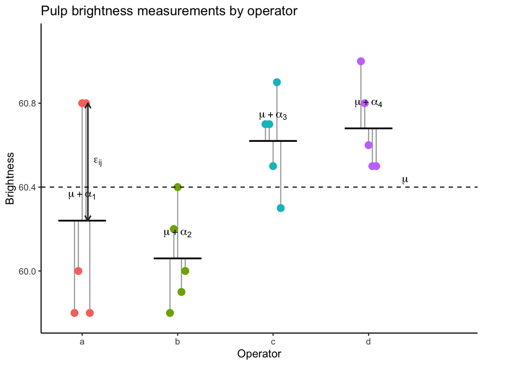

```r
pulp_plot <- pulp |>
  group_by(operator) |>
  mutate(
    operator_id = as.integer(operator),
    x_jitter = operator_id + seq(-0.08, 0.08, length.out = n()),
    mean_bright = mean(bright)
  ) |>
  ungroup()

pulp_means <- pulp_plot |>
  distinct(operator, operator_id, mean_bright) |>
  mutate(
    mean_label = paste0("mu + alpha[", row_number(), "]"),
    label_y = mean_bright + 0.12
  )

overall_mean <- mean(pulp$bright)
overall_mean_label_x <- length(levels(pulp$operator)) + 0.35

within_variation_label <- pulp_plot |>
  slice_max(abs(bright - mean_bright), n = 1, with_ties = FALSE) |>
  mutate(
    label_x = x_jitter + 0.12,
    label_y = (bright + mean_bright) / 2
  )

ggplot(pulp_plot, aes(x = x_jitter, y = bright, color = operator)) +
  geom_segment(
    aes(xend = x_jitter, y = mean_bright, yend = bright),
    color = "gray65",
    linewidth = 0.5,
    show.legend = FALSE
  ) +
  geom_segment(
    data = pulp_means,
    aes(
      x = operator_id - 0.25,
      xend = operator_id + 0.25,
      y = mean_bright,
      yend = mean_bright
    ),
    inherit.aes = FALSE,
    color = "black",
    linewidth = 0.8
  ) +
  geom_point(size = 3) +
  geom_segment(
    data = within_variation_label,
    aes(
      x = x_jitter + 0.06,
      xend = x_jitter + 0.06,
      y = mean_bright,
      yend = bright
    ),
    inherit.aes = FALSE,
    color = "gray20",
    linewidth = 0.7,
    arrow = grid::arrow(
      ends = "both",
      length = grid::unit(0.08, "inches")
    )
  ) +
  geom_text(
    data = within_variation_label,
    aes(x = label_x, y = label_y),
    label = "epsilon[ij]",
    color = "gray20",
    hjust = 0,
    parse = TRUE,
    inherit.aes = FALSE
  ) +
  geom_text(
    data = pulp_means,
    aes(x = operator_id, y = label_y, label = mean_label),
    color = "black",
    parse = TRUE,
    inherit.aes = FALSE,
    show.legend = FALSE
  ) +
  geom_hline(yintercept = overall_mean, linetype = 2) +
  annotate(
    "text",
    x = overall_mean_label_x,
    y = overall_mean,
    label = "mu",
    parse = TRUE,
    hjust = 0,
    vjust = -0.4
  ) +
  scale_x_continuous(
    breaks = seq_along(levels(pulp$operator)),
    labels = levels(pulp$operator),
    expand = expansion(mult = c(0.05, 0.22))
  ) +
  scale_y_continuous(expand = expansion(mult = c(0.08, 0.15))) +
  labs(
    x = "Operator",
    y = "Brightness",
    title = "Pulp brightness measurements by operator"
  ) +
  coord_cartesian(clip = "off") +
  theme_bw() +
  theme(
    legend.position = "none",
    plot.margin = margin(5.5, 34, 5.5, 5.5),
    axis.line = element_line(colour = "black"),
    panel.grid.major = element_blank(),
    panel.grid.minor = element_blank(),
    panel.border = element_blank(),
    panel.background = element_blank()
  )
```

## Model setup

The balanced one-way random-effects model is

$$y_{ij} = \mu + \alpha_i + \epsilon_{ij},
\qquad i = 1,\ldots,a,\quad j = 1,\ldots,n,$$

where

$$\alpha_i \overset{iid}{\sim} N(0,\sigma_\alpha^2),
\qquad
\epsilon_{ij} \overset{iid}{\sim} N(0,\sigma_\epsilon^2).$$

Here:

- $\mu$ is the overall mean.
- $\alpha_i$ is the random effect for group/operator $i$.
- $\sigma_\alpha^2$ is the between-group variance.
- $\sigma_\epsilon^2$ is the within-group variance.

## Part 1: ANOVA estimators

### Step 1: Start with the two means

Ask students to write the group mean:

$$\bar y_{i\cdot}
=
\frac{1}{n}\sum_{j=1}^n y_{ij}.$$

Using the model,

$$\bar y_{i\cdot}
=
\mu+\alpha_i+\bar\epsilon_{i\cdot}.$$

The grand mean is

$$\bar y_{\cdot\cdot}
=
\frac{1}{a}\sum_{i=1}^a \bar y_{i\cdot}
=
\mu+\bar\alpha_{\cdot}+\bar\epsilon_{\cdot\cdot}.$$

### Step 2: Derive the expectation of SSE

The within-group sum of squares is

$$SSE
=
\sum_{i=1}^a\sum_{j=1}^n
(y_{ij}-\bar y_{i\cdot})^2.$$

Now subtract the group mean:

$$\begin{aligned}
y_{ij}-\bar y_{i\cdot}
&=
(\mu+\alpha_i+\epsilon_{ij})
-
(\mu+\alpha_i+\bar\epsilon_{i\cdot}) \\
&=
\epsilon_{ij}-\bar\epsilon_{i\cdot}.
\end{aligned}$$

So the group effect disappears. What does SSE measure after $\mu$ and $\alpha_i$ cancel? Answer: only within-group noise.

For a fixed group $i$,

$$\sum_{j=1}^n(\epsilon_{ij}-\bar\epsilon_{i\cdot})^2$$

is the usual sample sum of squares from $n$ iid observations with variance $\sigma_\epsilon^2$. Therefore

$$E\left[
\sum_{j=1}^n(\epsilon_{ij}-\bar\epsilon_{i\cdot})^2
\right]
=
(n-1)\sigma_\epsilon^2.$$

There are $a$ groups, so

$$E(SSE)
=
a(n-1)\sigma_\epsilon^2.$$

Therefore

$$\widehat{\sigma}_\epsilon^2
=
\frac{SSE}{a(n-1)}
=
MS_E.$$

### Step 3: Derive the expectation of SSA

The between-group sum of squares is

$$SSA
=
\sum_{i=1}^a\sum_{j=1}^n
(\bar y_{i\cdot}-\bar y_{\cdot\cdot})^2.$$

Since the expression inside does not depend on $j$,

$$SSA
=
n\sum_{i=1}^a
(\bar y_{i\cdot}-\bar y_{\cdot\cdot})^2.$$

Now use

$$\bar y_{i\cdot}
=
\mu+\alpha_i+\bar\epsilon_{i\cdot}.$$

Define

$$u_i = \alpha_i+\bar\epsilon_{i\cdot}.$$

Then

$$\bar y_{i\cdot} = \mu + u_i,$$

and

$$\bar y_{i\cdot}-\bar y_{\cdot\cdot}
=
u_i-\bar u_{\cdot}.$$

Now compute the variance of $u_i$:

$$\begin{aligned}
Var(u_i)
&=
Var(\alpha_i+\bar\epsilon_{i\cdot}) \\
&=
Var(\alpha_i)+Var(\bar\epsilon_{i\cdot}) \\
&=
\sigma_\alpha^2+\frac{\sigma_\epsilon^2}{n}.
\end{aligned}$$

For iid $u_1,\ldots,u_a$,

$$E\left[
\sum_{i=1}^a(u_i-\bar u_{\cdot})^2
\right]
=
(a-1)Var(u_i).$$

Therefore

$$\begin{aligned}
E(SSA)
&=
n(a-1)
\left(
\sigma_\alpha^2+\frac{\sigma_\epsilon^2}{n}
\right) \\
&=
(a-1)(n\sigma_\alpha^2+\sigma_\epsilon^2).
\end{aligned}$$

So

$$MS_A
=
\frac{SSA}{a-1}$$

has expectation

$$E(MS_A)
=
n\sigma_\alpha^2+\sigma_\epsilon^2.$$

Since

$$E(MS_E)=\sigma_\epsilon^2,$$

we get

$$\widehat{\sigma}_\alpha^2
=
\frac{MS_A-MS_E}{n}.$$

### Step 4: ANOVA estimator summary

The ANOVA estimators are

$$\widehat{\mu}
=
\bar y_{\cdot\cdot},$$

$$\widehat{\sigma}_\epsilon^2
=
MS_E
=
\frac{SSE}{a(n-1)},$$

and

$$\widehat{\sigma}_\alpha^2
=
\frac{MS_A-MS_E}{n}
=
\frac{SSA/(a-1)-SSE/[a(n-1)]}{n}.$$

## Pulp data: compute ANOVA quantities by hand

```r
y <- pulp$bright
g <- pulp$operator

a <- nlevels(g)
n <- as.integer(table(g)[1])

group_means <- tapply(y, g, mean)
grand_mean <- mean(y)

SSE <- sum((y - ave(y, g))^2)
SSA <- sum(as.numeric(table(g)) * (group_means - grand_mean)^2)

MS_E <- SSE / (a * (n - 1))
MS_A <- SSA / (a - 1)

sigma2_e_anova <- MS_E
sigma2_a_anova <- (MS_A - MS_E) / n

c(
  a = a,
  n = n,
  grand_mean = grand_mean,
  SSE = SSE,
  SSA = SSA,
  MS_E = MS_E,
  MS_A = MS_A,
  sigma2_e_anova = sigma2_e_anova,
  sigma2_a_anova = sigma2_a_anova
)
```

```
             a              n     grand_mean            SSE            SSA
    4.00000000     5.00000000    60.40000000     1.70000000     1.34000000
          MS_E           MS_A sigma2_e_anova sigma2_a_anova
    0.10625000     0.44666667     0.10625000     0.06808333
```

## Part 2: MLE hints and derivation

### Step 1: Write the marginal distribution for one group

For group $i$, write the vector

$$\mathbf y_i
=
\begin{pmatrix}
y_{i1} \\
\vdots \\
y_{in}
\end{pmatrix}.$$

Because

$$\mathbf y_i
=
\mu\mathbf 1_n+\alpha_i\mathbf 1_n+\boldsymbol\epsilon_i,$$

we have marginally

$$\mathbf y_i
\sim
N(\mu\mathbf 1_n,V),$$

where

$$V
=
\sigma_\alpha^2\mathbf 1_n\mathbf 1_n^T
+
\sigma_\epsilon^2I_n.$$

For $j\ne k$,

$$Cov(y_{ij},y_{ik})
=
\sigma_\alpha^2.$$

For $j=k$,

$$Var(y_{ij})
=
\sigma_\alpha^2+\sigma_\epsilon^2.$$

### Step 2: Matrix facts for the likelihood

The log-likelihood uses $V^{-1}$ and $\det(V)$.

By the Woodbury formula,

$$V^{-1}
=
\sigma_\epsilon^{-2}I_n
-
\frac{\sigma_\epsilon^{-2}\sigma_\alpha^2}
{\sigma_\epsilon^2+n\sigma_\alpha^2}
\mathbf 1_n\mathbf 1_n^T.$$

Also,

$$\det(V)
=
\sigma_\epsilon^{2n}
\left(
1+n\frac{\sigma_\alpha^2}{\sigma_\epsilon^2}
\right).$$

Now define

$$\lambda
=
\frac{\sigma_\alpha^2}{\sigma_\epsilon^2}.$$

This gives

$$\det(V)
=
\sigma_\epsilon^{2n}(1+n\lambda).$$

### Step 3: Profile over $\mu$

The log-likelihood is maximized in $\mu$ at

$$\widehat\mu
=
\bar y_{\cdot\cdot}.$$

After setting $\mu=\bar y_{\cdot\cdot}$, the likelihood can be written using only $SSE$ and $SSA$.

### Step 4: Profile over $\sigma_\epsilon^2$

After reparameterizing by $\lambda$, the profiled estimate of $\sigma_\epsilon^2$ satisfies

$$\widehat\sigma_\epsilon^2(\lambda)
=
\frac{SST+n\lambda\,SSE}{na(1+n\lambda)}.$$

Equivalently,

$$\widehat\sigma_\epsilon^2(\lambda)
=
\frac{SST-\frac{n\lambda}{1+n\lambda}SSA}{na}.$$

The only remaining unknown is $\lambda$.

### Step 5: Maximize over $\lambda$

After profiling out $\mu$ and $\sigma_\epsilon^2$, the likelihood reduces to maximizing

$$-\frac{na}{2}\log(SST+n\lambda\,SSE)+\frac{(n-1)a}{2}\log(1+n\lambda).$$

Taking the derivative with respect to $\lambda$ and setting it equal to zero gives

$$\widehat\lambda
=
\frac{n-1}{n}\frac{SST}{SSE}-1.$$

Substituting this back gives

$$\widehat\sigma_{\epsilon,MLE}^2
=
\frac{SSE}{a(n-1)}.$$

So the MLE and ANOVA estimators for $\sigma_\epsilon^2$ agree in this balanced case.

For the between-group variance,

$$\widehat\sigma_{\alpha,MLE}^2
=
\frac{SSA}{an}
-
\frac{SSE}{an(n-1)}.$$

Compare this with ANOVA:

$$\widehat\sigma_{\alpha,ANOVA}^2
=
\frac{SSA}{(a-1)n}
-
\frac{SSE}{a(n-1)n}.$$

MLE is usually smaller because it uses $a$ instead of $a-1$ for the between-group component. It does not make the same degrees-of-freedom correction.

### Pulp data: MLE calculation

```r
SST <- sum((y - grand_mean)^2)

sigma2_e_mle <- SSE / (a * (n - 1))
sigma2_a_mle <- SSA / (a * n) - SSE / (a * n * (n - 1))

c(
  SST = SST,
  sigma2_e_mle = sigma2_e_mle,
  sigma2_a_mle = sigma2_a_mle,
  sigma2_e_anova = sigma2_e_anova,
  sigma2_a_anova = sigma2_a_anova
)
```

```
           SST   sigma2_e_mle   sigma2_a_mle sigma2_e_anova sigma2_a_anova
    3.04000000     0.10625000     0.04575000     0.10625000     0.06808333
```

## Part 3: REML hints

### Step 1: The conceptual issue

MLE estimates variance components after also estimating $\mu$. REML adjusts for that lost fixed-effect degree of freedom.

Here the fixed-effect design matrix is just

$$X=\mathbf 1_{na}.$$

So REML removes the direction spanned by $\mathbf 1_{na}$.

### Step 2: The projection-like matrix

Let

$$\Omega
=
\sigma_\alpha^2ZZ^T+\sigma_\epsilon^2I.$$

The REML likelihood involves

$$P
=
\Omega^{-1}
-
\Omega^{-1}X(X^T\Omega^{-1}X)^{-1}X^T\Omega^{-1}.$$

This matrix keeps variation orthogonal to the fixed effect.

### Step 3: Balanced one-way conclusion

In the balanced one-way random-effects model, REML gives the same variance component estimates as ANOVA:

$$\widehat{\sigma}_{\epsilon,REML}^2
=
MS_E,$$

and

$$\widehat{\sigma}_{\alpha,REML}^2
=
\frac{MS_A-MS_E}{n}.$$

REML agrees with ANOVA here because both methods account for the degree of freedom used to estimate the overall mean.

## Part 4: Posterior mean of random effects

Now consider the conditional model

$$\mathbf y\mid\boldsymbol\gamma
\sim
N(X\beta+Z\boldsymbol\gamma,\sigma^2I),$$

and the prior

$$\boldsymbol\gamma
\sim
N(0,\Sigma).$$

### Step 1: Multiply likelihood by prior

By Bayes’ theorem,

$$f(\boldsymbol\gamma\mid\mathbf y)
\propto
f(\mathbf y\mid\boldsymbol\gamma)
f(\boldsymbol\gamma).$$

Ignoring constants, the exponent is

$$-\frac{1}{2\sigma^2} \|\mathbf y-X\beta-Z\boldsymbol\gamma\|^2 -\frac{1}{2}\boldsymbol\gamma^T\Sigma^{-1}\boldsymbol\gamma.$$

### Step 2: Collect quadratic and linear terms

Let

$$\mathbf r=\mathbf y-X\beta.$$

Then

$$\|\mathbf r-Z\boldsymbol\gamma\|^2
=
\mathbf r^T\mathbf r
-
2\boldsymbol\gamma^TZ^T\mathbf r
+
\boldsymbol\gamma^TZ^TZ\boldsymbol\gamma.$$

Keeping only terms involving $\boldsymbol\gamma$, the negative exponent is proportional to

$$\frac{1}{2}
\boldsymbol\gamma^T
\left(
\sigma^{-2}Z^TZ+\Sigma^{-1}
\right)
\boldsymbol\gamma
-
\boldsymbol\gamma^T
\sigma^{-2}Z^T(\mathbf y-X\beta).$$

Therefore the posterior precision matrix is

$$\sigma^{-2}Z^TZ+\Sigma^{-1}.$$

So the posterior covariance is

$$\left(
\sigma^{-2}Z^TZ+\Sigma^{-1}
\right)^{-1}.$$

The posterior mean is

$$E(\boldsymbol\gamma\mid \mathbf y)
=
\left(
\sigma^{-2}Z^TZ+\Sigma^{-1}
\right)^{-1}
\sigma^{-2}Z^T(\mathbf y-X\beta).$$

Using the matrix inversion identity, this is equivalent to

$$E(\boldsymbol\gamma\mid \mathbf y)
=
\Sigma Z^T
\left(
Z\Sigma Z^T+\sigma^2I
\right)^{-1}
(\mathbf y-X\beta).$$

### Step 3: Specialize to balanced one-way ANOVA

For the one-way random-effects model,

$$\Sigma=\sigma_\alpha^2I_a,
\qquad
\sigma^2=\sigma_\epsilon^2.$$

Also,

$$Z^TZ=nI_a.$$

The posterior mean is

$$\begin{aligned}
E(\boldsymbol\alpha\mid y)
&=
\left(
\sigma_\epsilon^{-2}nI_a+\sigma_\alpha^{-2}I_a
\right)^{-1}
\sigma_\epsilon^{-2}Z^T(y-\mu\mathbf 1) \\
&=
\frac{\sigma_\alpha^2}{\sigma_\epsilon^2+n\sigma_\alpha^2}
Z^T(y-\mu\mathbf 1).
\end{aligned}$$

For group $i$,

$$Z_i^T(y-\mu\mathbf 1)
=
\sum_{j=1}^n(y_{ij}-\mu)
=
n(\bar y_{i\cdot}-\mu).$$

So

$$E(\alpha_i\mid y)
=
\frac{n\sigma_\alpha^2}
{\sigma_\epsilon^2+n\sigma_\alpha^2}
(\bar y_{i\cdot}-\mu).$$

Equivalently,

$$E(\alpha_i\mid y)
=
\frac{1}
{1+\sigma_\epsilon^2/(n\sigma_\alpha^2)}
\hat\alpha_i,$$

where

$$\hat\alpha_i=\bar y_{i\cdot}-\mu.$$

The multiplier

$$\frac{1}
{1+\sigma_\epsilon^2/(n\sigma_\alpha^2)}$$

is between 0 and 1.

An extreme group mean may reflect a true group effect, but it may also reflect noise. The model compromises by pulling it toward the overall mean.

## Pulp data: visualize shrinkage

```r
shrinkage_factor <- n * sigma2_a_anova / (n * sigma2_a_anova + sigma2_e_anova)

effects <- tibble(
  operator = names(group_means),
  fixed_effect_estimate = as.numeric(group_means - grand_mean),
  posterior_random_effect = shrinkage_factor * fixed_effect_estimate
)

effects
```

```
# A tibble: 4 × 3
  operator fixed_effect_estimate posterior_random_effect
  <chr>                    <dbl>                   <dbl>
1 a                       -0.160                  -0.122
2 b                       -0.340                  -0.259
3 c                        0.220                   0.168
4 d                        0.280                   0.213
```

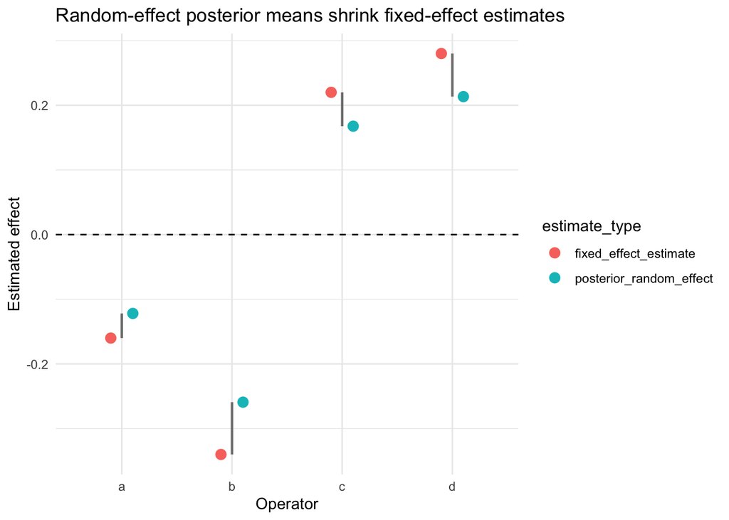

```r
effects_long <- effects |>
  pivot_longer(
    cols = c(fixed_effect_estimate, posterior_random_effect),
    names_to = "estimate_type",
    values_to = "effect"
  )

ggplot(effects_long, aes(x = operator, y = effect, color = estimate_type)) +
  geom_hline(yintercept = 0, linetype = 2) +
  geom_point(size = 3, position = position_dodge(width = 0.4)) +
  geom_segment(
    data = effects,
    aes(
      x = operator,
      xend = operator,
      y = fixed_effect_estimate,
      yend = posterior_random_effect
    ),
    inherit.aes = FALSE,
    color = "gray50",
    linewidth = 0.8
  ) +
  labs(
    x = "Operator",
    y = "Estimated effect",
    title = "Random-effect posterior means shrink fixed-effect estimates"
  ) +
  theme_minimal()
```

## Final class summary

Use this as the closing slide or board summary:

1. Within groups:

$$SSE \Rightarrow \sigma_\epsilon^2.$$

2. Between group means:

$$SSA \Rightarrow n\sigma_\alpha^2+\sigma_\epsilon^2.$$

3. ANOVA and REML correct for estimating the overall mean:

$$\widehat{\sigma}_\alpha^2
=
\frac{MS_A-MS_E}{n}.$$

4. MLE is similar, but usually estimates the between-group variance smaller.
5. Posterior random effects are shrunken fixed-effect estimates:

$$E(\alpha_i\mid y)=c\hat\alpha_i,
\qquad 0<c<1.$$

One-sentence takeaway: SSE measures noise, SSA measures group variation plus noise, and random-effect predictions shrink noisy group differences toward the grand mean.